# Assignment 2 - Web data

Simon Marcell Matei - mateism

October 16, 2025 | 19:20:42 | CEST

```r
library(pacman)
pacman::p_load(tidyverse, rvest, xml2, janitor, knitr, httr, jsonlite)
```

### Task 1 - Regular expressions and XPath with Friends

Choose **one of the following** tasks (a) or (b) to complete:

1. Extract information about the first six UN Secretary Generals from a messy string using regular expressions and store the data in a data frame (`unsg_df`). The resulting data frame should be formatted with the following columns and data types:

| Variable | Data type |
| --- | --- |
| `name` | `<chr>` |
| `assumed_office` | `<date>` |
| `left_office` | `<date>` |
| `country_of_origin` | `<chr>` |
| `un_regional_group` | `<chr>` |

Render the data frame as HTML table.

```r
url_unsg <- read_html("https://en.wikipedia.org/wiki/Secretary-General_of_the_United_Nations")
```

```r
unsg_table_raw <- html_table(url_unsg, header = T) |>
  pluck(2) |>
  clean_names()

unsg_df <-  unsg_table_raw |>
  slice(2:12) |>
  select(-c(portrait, term_of_office_3, notes)) |>
  filter(no != "Acting") |> #making sure only numbered secretary generals are included
  slice(1:6) |>
  select(-no) |>
  mutate(
    name_born_died = str_extract(name_born_died, "[[:alpha:]|\\s|\\-]+"),
    term_of_office_2 = str_extract(term_of_office_2, "[[:alnum:]|\\s]+"), #removing any additional characters that aren't part of the date
    term_of_office = dmy(term_of_office),
    term_of_office_2 = dmy(term_of_office_2)
    )

colnames(unsg_df) <- c("name", "assumed_office", "left_office", "country_of_origin", "un_regional_group")

glimpse(unsg_df)
```

```
Rows: 6
Columns: 5
$ name              <chr> "Trygve Lie", "Dag Hammarskjöld", "U Thant", "Kurt W…
$ assumed_office    <date> 1946-02-02, 1953-04-10, 1962-11-30, 1972-01-01, 198…
$ left_office       <date> 1952-11-10, 1961-09-18, 1971-12-31, 1981-12-31, 199…
$ country_of_origin <chr> "Norway", "Sweden", "Burma", "Austria", "Peru", "Egy…
$ un_regional_group <chr> "Western European and Others", "Western European and…
```

```r
kable(unsg_df)
```

| name | assumed_office | left_office | country_of_origin | un_regional_group |
| --- | --- | --- | --- | --- |
| Trygve Lie | 1946-02-02 | 1952-11-10 | Norway | Western European and Others |
| Dag Hammarskjöld | 1953-04-10 | 1961-09-18 | Sweden | Western European and Others |
| U Thant | 1962-11-30 | 1971-12-31 | Burma | Asia-Pacific |
| Kurt Waldheim | 1972-01-01 | 1981-12-31 | Austria | Western European and Others |
| Javier Pérez de Cuéllar | 1982-01-01 | 1991-12-31 | Peru | Latin American and Caribbean |
| Boutros Boutros-Ghali | 1992-01-01 | 1996-12-31 | Egypt | African |

2. The file `friends_info.xml` contains information about all episodes from the TV series Friends (accessible at https://raw.githubusercontent.com/intro-to-data-science-24/labs/main/data/friends_info.xml). Import the file using the `xml2::read_xml()` function. *(Hint: this is an XML document, so you will need to use the xml analogues of `rvest::read_html()`, `rvest::html_nodes()`, and `rvest::html_text()`)*.
- Use XPath expressions to extract the season, episode number, and title of all episodes. Store this information in a data frame (`episode_df`) and render the first 5 rows as an HTML table.
- Use XPath expressions to return the vector `directed_by_ross` providing the titles of all episodes directed by Ross himself (**David Schwimmer**).
- Create a chart that reports the frequency of episodes mentioning one of the six main characters (Ross, Rachel, Monica, Chandler, Joey, Phoebe) in the title.

```r
#doing b) as well for practice
friends_data <- read_xml("https://raw.githubusercontent.com/intro-to-data-science-24/labs/main/data/friends_info.xml")
```

```r
# season <- friends_data |>
#   html_elements(xpath = "//season") |>
#   html_text()
# episode <- friends_data |>
#   html_elements(xpath = "//episode_number") |>
#   html_text()
# title <- friends_data |>
#   html_elements(xpath = "//title") |>
#   html_text()
#
# episode_df_test <- tibble(
#   season = season,
#   episode = episode,
#   title = title)

#Rewritten more elegantly after consulting slides from previous weeks about purrr::map() and asking GPT 5 how to make the code above more concise using it:
paths <- c(
  season  = "//season",
  episode = "//episode_number",
  title   = "//title"
)

episode_df <- paths |>
  map(~ friends_data |> html_elements(xpath = .x) |> html_text()) |>
  as_tibble()

kable(episode_df[1:5,])
```

| season | episode | title |
| --- | --- | --- |
| 1 | 1 | The Pilot |
| 1 | 2 | The One with the Sonogram at the End |
| 1 | 3 | The One with the Thumb |
| 1 | 4 | The One with George Stephanopoulos |
| 1 | 5 | The One with the East German Laundry Detergent |

```r
#Getting episode titles directed by Ross
directed_by_ross <- friends_data |>
  html_elements(xpath = "//directed_by[contains(text(), 'David Schwimmer')]/preceding-sibling::title") |>
  html_text()
print("Episodes directed by Ross (David Schwimmer):")
```

```
[1] "Episodes directed by Ross (David Schwimmer):"
```

```r
directed_by_ross
```

```
 [1] "The One on the Last Night"
 [2] "The One with Rachel's Assistant"
 [3] "The One with Ross's Library Book"
 [4] "The One with All the Candy"
 [5] "The One with the Truth About London"
 [6] "The One with the Red Sweater"
 [7] "The One with the Stripper"
 [8] "The One Where Joey Dates Rachel"
 [9] "The One with Phoebe's Birthday Dinner"
[10] "The One with the Birth Mother"
```

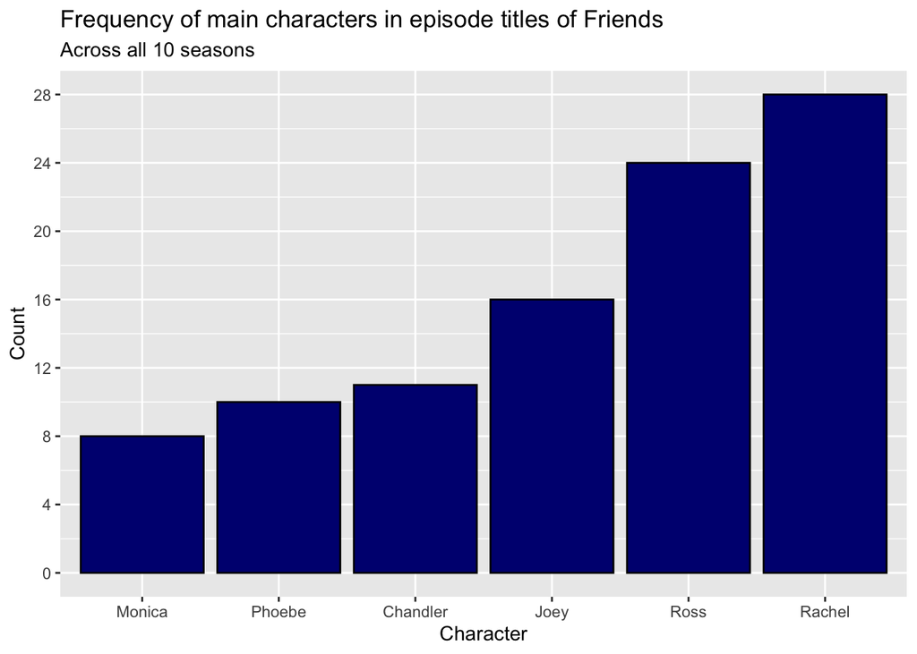

```r
#Chart showing frequency of different characters appearing in the title

# character_df <- episode_df |>
#   mutate(
#     ross = str_detect(title, "Ross"), #words such as Cross shouldn't be mathced since str_detect is case sensitive unless specifed otherwise
#     rachel = str_detect(title, "Rachel"),
#     monica = str_detect(title, "Monica"),
#     chandler = str_detect(title, "Chandler"),
#     joey = str_detect(title, "Joey"),
#     phoebe = str_detect(title, "Phoebe")
#   ) |>
#   select(ross, rachel, monica, chandler, joey, phoebe) |>
#   mutate(
#     ross_n = sum(ross),
#     rachel_n = sum(rachel),
#     monica_n = sum(monica),
#     chandler_n = sum(chandler),
#     joey_n = sum(joey),
#     phoebe_n = sum(phoebe)
#   ) |>
#   select(ross_n, rachel_n, monica_n, chandler_n, joey_n, phoebe_n) |>
#   slice(1)

#Origianlly had the idea to do it more elegantly with map but couldn't figure it out at first so I coded it out to get the intuition of what needs to happen
characters <- c("Ross", "Rachel", "Monica", "Chandler", "Joey", "Phoebe")
character_counts_df <- tibble(
  character = characters,
  n = map_int(characters, ~ sum(str_detect(episode_df$title, fixed(.x)), na.rm = TRUE))
)

ggplot(character_counts_df, aes(x = fct_reorder(character, n), y = n)) +
  geom_col(colour = "black", fill = "navy") +
  labs(
    title = "Frequency of main characters in episode titles of Friends",
    subtitle = "Across all 10 seasons",
    x = "Character",
    y = "Count"
  ) +
  scale_y_continuous(breaks = seq(0, 30, by = 4))
```

### Task 2 - Scraping members of the European Parliament

The European Parliament’s website maintains a [full list of MEPs](https://www.europarl.europa.eu/meps/en/full-list/all). For this exercise, you will focus on scraping data from the HTML code, so please don’t make use of the linked XML files.

1. Extract a data frame (`meps_df`) with the variables listed below, print the first 3 observations, and check the number of rows.

| Variable | Data type | Description |
| --- | --- | --- |
| `name` | `<chr>` | Full name of MEP |
| `ep_party_group` | `<chr>` | EP party group |
| `country` | `<chr>` | Country of MEP |
| `nat_party` | `<chr>` | National party of MEP |
| `profile_url` | `<chr>` | URL linking to MEP profile |
| `mep_id` | `<chr>` | MEP numeric identifier included as a path in `profile_url` |

```r
#An MEP was removed from the website as of 14 Oct. 2025 so the number of rows went from 719 to 718 after rerunning the code.
url_mep <- read_html("https://www.europarl.europa.eu/meps/en/full-list/all")
```

```r
meps_paths <- c(
  name = "//div[contains(@class, 'erpl_title-h4')]",
  ep_party_group = "//div/span[contains(@class, 'sln-additional-info')][1]",
  country = "//div/span[contains(@class, 'sln-additional-info')][2]",
  nat_party = "//div/span[contains(@class, 'sln-additional-info')][3]",
  profile_url = "//a[contains(@class, 'erpl_member-list-item-content mb-3 t-y-block')]"
)
meps_df <- meps_paths |>
  map(~ {
    nodes <- url_mep |> html_elements(xpath = .x)
    if (.x == meps_paths[["profile_url"]]) {
      html_attr(nodes, "href")
    } else {
      html_text(nodes)
    }
  }) |>
  as_tibble() |>
  mutate(mep_id = str_extract(profile_url, "[[:digit:]]+$"))

head(meps_df, 3)
```

| name | ep_party_group | country | nat_party | profile_url | mep_id |
| --- | --- | --- | --- | --- | --- |
| Mika AALTOLA | Group of the European People's Party (Christian Democrats) | Finland | Kansallinen Kokoomus | https://www.europarl.europa.eu/meps/en/256810 | 256810 |
| Maravillas ABADÍA JOVER | Group of the European People's Party (Christian Democrats) | Spain | Partido Popular | https://www.europarl.europa.eu/meps/en/257043 | 257043 |
| Magdalena ADAMOWICZ | Group of the European People's Party (Christian Democrats) | Poland | Independent | https://www.europarl.europa.eu/meps/en/197490 | 197490 |

```r
print("Number of rows: ")
```

```
[1] "Number of rows: "
```

```r
nrow(meps_df)
```

```
[1] 718
```

2. Now, using the `profile_url` data in the table. Provide polite code that downloads the first 10 of the linked HTMLs to a local folder retaining the MEP IDs as file names.
- Explain why your code follows best practice of polite scraping by implementing at least three practices (bullet points are sufficient).
- Provide proof that the download was performed successfully by listing the file names and reporting the total number of files contained by the folder.
- Make sure that the folder itself is not synced to GitHub using `.gitignore`.

```r
folder <- "./html_mep_profiles/"
dir.create(folder, recursive = TRUE)

rvest_session <- rvest::session(url = "https://www.europarl.europa.eu",
                                httr::add_headers(
                                  `From` = "s.matei@students.hertie-school.org",
                                  `UserAgent` = R.Version()$version.string
                                  )
                                )

url_list <- meps_df$profile_url[1:10]
names_for_files <- meps_df$mep_id[1:10]

for (i in seq_along(url_list)) {
  out_path <- file.path(folder, paste0(names_for_files[i], ".html"))
  if (file.exists(out_path)) next

  tryCatch({
    # Navigate the session to the target URL. Then read HTML from the current session response and write to disk
    rvest_session |> session_jump_to(url_list[i]) |> read_html() |> write_html(out_path)
  }, error = function(e)
    e
  )

  Sys.sleep(runif(1, 0, 2))
}
```

Best practices of scraping used:

- Sleeping between requests to not bombard the server
- Storing files locally (and only downloading if the file doesn’t exist yet) before any downstream parsing to reduce load on server
- Staying identifiable through using `rvest::session()`

File names and nr. of files contained in the folder:

Using the terminal and `tree` command-line utility

```
├── README.md
├── assignment-2-mateism.Rproj
├── assignment-2.Rmd
├── assignment-2.html
└── html_mep_profiles
    ├── 113523.html
    ├── 197400.html
    ├── 197403.html
    ├── 197490.html
    ├── 256810.html
    ├── 256820.html
    ├── 256869.html
    ├── 256956.html
    ├── 256987.html
    └── 257043.html
```

- It contains 10 files

### Task 3 - Eat my shorts

Write an R function `get_simpsons_quote()` that wraps around the Simpsons API at https://thesimpsonsapi.com/.  
This function should:

- Fetch the JSON data from https://thesimpsonsapi.com/api/characters?page=1. Only consider the first page here and ignore the others.
- Accept the parameter `character`, which can be either a numeric ID or (part of) the character’s name.
- Accept the parameter `show.names` (default `FALSE`). If set to `TRUE`, the function should return the vector of valid character names available on the first page.
- If `show.names = FALSE`, the function should return a random phrase (`quote`) for the specified character.
- If multiple names match, it should use the first match but issue a warning.
- If no match is found, it should stop with a meaningful error.
- Internally, the function should parse the JSON into a `data.frame` (e.g., with `dplyr`) and then filter depending on the `character` argument.

The function should also return a meaningful message if `show.names = TRUE` (listing the available names) or if no quotes are available.

Test the function!

```r
get_simpsons_quote <- function(character_id, show.names = FALSE) {

  #checking for correctly specified arguments
  if(is.na(character_id) | (!is.character(character_id) & !is.numeric(character_id))) {
    stop("Argument character_id has to be numeric ID or (part of) character's name")
  }
  if(is.na(show.names) | !is.logical(show.names)) {
    stop("Argument show.names must be logical value")
  }

  #accessing the API and parsing the JSON
  parsed_json <- GET("https://thesimpsonsapi.com/api/characters?page=1") |>
    content(as = "text") |>
    fromJSON() |>
    pluck(5) |>  #since we only need the data contained in page 1 and won't use the information in the other values
    as_tibble()

  #finding the character(s) matching the input
  matching_names <- character()
  #finding match if numeric id is provided
  if(is.numeric(character_id)) {
    matching_names <- parsed_json |>
      filter(id == character_id) |>
      pull(name)
  }
  #finding match(es) if character type input is provided
  if(is.character(character_id)) {
    match_ids <- logical()
    for(i in seq_along(parsed_json$name)) {
      current_name <- parsed_json$name[i]
      match_ids[i] <- str_detect(current_name, character_id)
    }
    matching_names <- parsed_json$name[match_ids]
  }
  #Generating error if no match is found
  if(length(matching_names) == 0) {
    stop("No matching characters found based on input specified")
  }

  #generating quote to return
  quote_to_return <- parsed_json |>
    filter(name == matching_names[1]) |> #using the first matching name to generate quote
    select(phrases) |> #because of API call $phrases is a list column
    unlist() |>
    sample(size = 1) |>
    unname()

  #returning quotes
  if(show.names == FALSE) {
    if(length(matching_names) == 1) {
      return(quote_to_return)
    } else if(length(matching_names) > 1) {
      output_text <- paste0(quote_to_return, "\n\nWarning: quote generated for first matching character. Specify show.names = TRUE if interested in all matches")
    }
  }
  #returning quotes and names
  if(show.names == TRUE) {
    valid_names <- paste0(parsed_json |> pull(name), collapse = "\n")
    names_to_return <- paste0(matching_names, collapse = "\n")
    output_text <- paste0(quote_to_return, "\n\nMatching characters (quote generated for first match):\n", names_to_return, "\n\nAll valid names on page 1:\n", valid_names)
  }
  cat(output_text, "\n")
}
```

Testing the function

```r
get_simpsons_quote(character = "Homer", show.names = TRUE)
```

```
I am evil Ho-mer! I am evil Ho-mer! I am evil Ho-mer!

Matching characters (quote generated for first match):
Homer Simpson

All valid names on page 1:
Homer Simpson
Marge Simpson
Bart Simpson
Lisa Simpson
Maggie Simpson
Abe Simpson II
Patty Bouvier
Selma Bouvier
Ned Flanders
Maude Flanders
Rod Flanders
Todd Flanders
Charles Montgomery Burns
Waylon Smithers, Jr.
Krusty the Clown
Moe Szyslak
Apu Nahasapeemapetilon
Seymour Skinner
Gary Chalmers
Edna Krabappel
```

```r
get_simpsons_quote(character_id = 2)
```

```
[1] "Now its Marges time to shine!"
```

```r
get_simpsons_quote(character_id = "Simpson")
```

```
Shut up Flanders!

Warning: quote generated for first matching character. Specify show.names = TRUE if interested in all matches
```

```r
get_simpsons_quote(character_id = "Simpson", show.names = TRUE)
```

```
Marge, my face hurts again!

Matching characters (quote generated for first match):
Homer Simpson
Marge Simpson
Bart Simpson
Lisa Simpson
Maggie Simpson
Abe Simpson II

All valid names on page 1:
Homer Simpson
Marge Simpson
Bart Simpson
Lisa Simpson
Maggie Simpson
Abe Simpson II
Patty Bouvier
Selma Bouvier
Ned Flanders
Maude Flanders
Rod Flanders
Todd Flanders
Charles Montgomery Burns
Waylon Smithers, Jr.
Krusty the Clown
Moe Szyslak
Apu Nahasapeemapetilon
Seymour Skinner
Gary Chalmers
Edna Krabappel
```

```r
# get_simpsons_quote(character_id = "asdfgh") #to test error
```

### Bonus Task 3a (optional) - Eat my shorts Vol. 2

Enhance the `get_simpsons_quote()` function to:

- Import **all character pages** from the Simpsons API (not just page 1).
- Allow `show.names = TRUE` to return **all valid character names** across all pages.
- Add an additional argument meme (default FALSE). When meme = TRUE, the function should render a meme using the character’s image together with the randomly chosen quote. You may use packages like magick or a dedicated meme package in R to overlay the text on the image. The function should still return the quote text as output, but also display the generated meme.

```r
# YOUR CODE HERE
```